# yam-horin-notebook(4)

```python
# import numpy, matplotlib, etc.
import math
import numpy as np
import pandas as pd
import seaborn as sns
import matplotlib.pyplot as plt
# sklearn imports
import sklearn
from sklearn import metrics
from sklearn import datasets
from sklearn import pipeline
from sklearn import linear_model
from sklearn import preprocessing
from sklearn import model_selection
from sklearn.preprocessing import StandardScaler

# define plt settings
sns.set_theme()
plt.rcParams["font.size"] = 40
plt.rcParams["axes.labelsize"] = 40
plt.rcParams["xtick.labelsize"] = 40
plt.rcParams["ytick.labelsize"] = 40
plt.rcParams["legend.fontsize"] = 40
plt.rcParams["legend.markerscale"] = 1.5
plt.rcParams["figure.figsize"] = (20, 10)
plt.rcParams["legend.title_fontsize"] = 20
```

```python
#get the inputs
titanic_df = pd.read_csv('/kaggle/input/titanic/train.csv')
titanic_df_test = pd.read_csv('/kaggle/input/titanic/test.csv')
gender_submition = pd.read_csv('/kaggle/input/titanic/gender_submission.csv')
titanic_df_test
titanic_df
```

|  | PassengerId | Survived | Pclass | Name | Sex | Age | SibSp | Parch | Ticket | Fare | Cabin | Embarked |
| --- | --- | --- | --- | --- | --- | --- | --- | --- | --- | --- | --- | --- |
| 0 | 1 | 0 | 3 | Braund, Mr. Owen Harris | male | 22.0 | 1 | 0 | A/5 21171 | 7.2500 | NaN | S |
| 1 | 2 | 1 | 1 | Cumings, Mrs. John Bradley (Florence Briggs Th... | female | 38.0 | 1 | 0 | PC 17599 | 71.2833 | C85 | C |
| 2 | 3 | 1 | 3 | Heikkinen, Miss. Laina | female | 26.0 | 0 | 0 | STON/O2. 3101282 | 7.9250 | NaN | S |
| 3 | 4 | 1 | 1 | Futrelle, Mrs. Jacques Heath (Lily May Peel) | female | 35.0 | 1 | 0 | 113803 | 53.1000 | C123 | S |
| 4 | 5 | 0 | 3 | Allen, Mr. William Henry | male | 35.0 | 0 | 0 | 373450 | 8.0500 | NaN | S |
| ... | ... | ... | ... | ... | ... | ... | ... | ... | ... | ... | ... | ... |
| 886 | 887 | 0 | 2 | Montvila, Rev. Juozas | male | 27.0 | 0 | 0 | 211536 | 13.0000 | NaN | S |
| 887 | 888 | 1 | 1 | Graham, Miss. Margaret Edith | female | 19.0 | 0 | 0 | 112053 | 30.0000 | B42 | S |
| 888 | 889 | 0 | 3 | Johnston, Miss. Catherine Helen "Carrie" | female | NaN | 1 | 2 | W./C. 6607 | 23.4500 | NaN | S |
| 889 | 890 | 1 | 1 | Behr, Mr. Karl Howell | male | 26.0 | 0 | 0 | 111369 | 30.0000 | C148 | C |
| 890 | 891 | 0 | 3 | Dooley, Mr. Patrick | male | 32.0 | 0 | 0 | 370376 | 7.7500 | NaN | Q |

891 rows × 12 columns

# let's fill the NULL places and normelize the data that we can

```python
#check if there is null items
np.where(titanic_df.isnull())
```

[output not shown]

[output cut: 103 more lines]

what is the data types?

```python
titanic_df.dtypes
```

```
PassengerId      int64
Survived         int64
Pclass           int64
Name            object
Sex             object
Age            float64
SibSp            int64
Parch            int64
Ticket          object
Fare           float64
Cabin           object
Embarked        object
dtype: object
```

```python
print('check if titanic_df has nulls:')
print('------------------------------')
print(titanic_df.isnull().sum())
print('check if titanic_df_test has nulls:')
print('------------------------------')
print(titanic_df_test.isnull().sum())
```

```
check if titanic_df has nulls:
------------------------------
PassengerId      0
Survived         0
Pclass           0
Name             0
Sex              0
Age            177
SibSp            0
Parch            0
Ticket           0
Fare             0
Cabin          687
Embarked         2
dtype: int64
check if titanic_df_test has nulls:
------------------------------
PassengerId      0
Pclass           0
Name             0
Sex              0
Age             86
SibSp            0
Parch            0
Ticket           0
Fare             1
Cabin          327
Embarked         0
dtype: int64
```

```python
# completion of missing values in train
# fill empty values in the dataframe

def fill_na_mean(df, column_name):
    df_not_null = df[~df[column_name].isnull()]
    mean_value = df_not_null[column_name].mean()
    df[column_name] = df[column_name].fillna(mean_value)

def fill_na_random_pick_column_distribution(df, column_name):
    df_not_null = df[~df[column_name].isnull()]
    random_values = np.random.choice(df_not_null[column_name], size=df[column_name].isnull().sum())
    df.loc[df[column_name].isnull(), column_name] = random_values

# Example usage
fill_na_random_pick_column_distribution(titanic_df, 'Cabin')
fill_na_random_pick_column_distribution(titanic_df, 'Embarked')
fill_na_random_pick_column_distribution(titanic_df_test, 'Cabin')
fill_na_random_pick_column_distribution(titanic_df_test, 'Embarked')
fill_na_random_pick_column_distribution(titanic_df_test, 'Fare')
```

```python
print(titanic_df.isnull().sum())
print('')
print(titanic_df_test.isnull().sum())
```

```
PassengerId      0
Survived         0
Pclass           0
Name             0
Sex              0
Age            177
SibSp            0
Parch            0
Ticket           0
Fare             0
Cabin            0
Embarked         0
dtype: int64

PassengerId     0
Pclass          0
Name            0
Sex             0
Age            86
SibSp           0
Parch           0
Ticket          0
Fare            0
Cabin           0
Embarked        0
dtype: int64
```

```python
    #get the null boxes for the age collu
    df_not_null = titanic_df[~titanic_df['Age'].isnull()]
    median_value = df_not_null['Age'].median()
    print(f"median_value train {median_value}")
    titanic_df['Age'] = titanic_df['Age'].fillna(median_value)
    df_not_null = titanic_df_test[~titanic_df_test['Age'].isnull()]
    median_value = df_not_null['Age'].median()
    print(f"median_value test {median_value}")
    titanic_df_test['Age'] = titanic_df_test['Age'].fillna(median_value)
```

```
median_value train 28.0
median_value test 27.0
```

```python
print(titanic_df.isnull().sum())
print('')
print(titanic_df_test.isnull().sum())
```

```
PassengerId    0
Survived       0
Pclass         0
Name           0
Sex            0
Age            0
SibSp          0
Parch          0
Ticket         0
Fare           0
Cabin          0
Embarked       0
dtype: int64

PassengerId    0
Pclass         0
Name           0
Sex            0
Age            0
SibSp          0
Parch          0
Ticket         0
Fare           0
Cabin          0
Embarked       0
dtype: int64
```

```python
#convert the sex and embarked catagories into numerci
from sklearn.preprocessing import OneHotEncoder
def dummy_encode(df, columns_names_list , drop  = 'if_binary'):
    df_cat = df[columns_names_list]
    enc = OneHotEncoder(drop = drop, sparse_output=False)
    df_cat_enc = pd.DataFrame(enc.fit_transform(df_cat),columns=enc.get_feature_names_out(columns_names_list))
    df_enc = df.drop(columns_names_list, axis=1).join(df_cat_enc)
    return df_enc

titanic_df = dummy_encode(titanic_df, ['Sex'] ,drop ='first')
titanic_df_test = dummy_encode(titanic_df_test, ['Sex'] ,drop ='first')
titanic_df_test
```

|  | PassengerId | Pclass | Name | Age | SibSp | Parch | Ticket | Fare | Cabin | Embarked | Sex_male |
| --- | --- | --- | --- | --- | --- | --- | --- | --- | --- | --- | --- |
| 0 | 892 | 3 | Kelly, Mr. James | 34.5 | 0 | 0 | 330911 | 7.8292 | D21 | Q | 1.0 |
| 1 | 893 | 3 | Wilkes, Mrs. James (Ellen Needs) | 47.0 | 1 | 0 | 363272 | 7.0000 | C89 | S | 0.0 |
| 2 | 894 | 2 | Myles, Mr. Thomas Francis | 62.0 | 0 | 0 | 240276 | 9.6875 | C31 | Q | 1.0 |
| 3 | 895 | 3 | Wirz, Mr. Albert | 27.0 | 0 | 0 | 315154 | 8.6625 | B78 | S | 1.0 |
| 4 | 896 | 3 | Hirvonen, Mrs. Alexander (Helga E Lindqvist) | 22.0 | 1 | 1 | 3101298 | 12.2875 | C116 | S | 0.0 |
| ... | ... | ... | ... | ... | ... | ... | ... | ... | ... | ... | ... |
| 413 | 1305 | 3 | Spector, Mr. Woolf | 27.0 | 0 | 0 | A.5. 3236 | 8.0500 | C6 | S | 1.0 |
| 414 | 1306 | 1 | Oliva y Ocana, Dona. Fermina | 39.0 | 0 | 0 | PC 17758 | 108.9000 | C105 | C | 0.0 |
| 415 | 1307 | 3 | Saether, Mr. Simon Sivertsen | 38.5 | 0 | 0 | SOTON/O.Q. 3101262 | 7.2500 | A21 | S | 1.0 |
| 416 | 1308 | 3 | Ware, Mr. Frederick | 27.0 | 0 | 0 | 359309 | 8.0500 | C89 | S | 1.0 |
| 417 | 1309 | 3 | Peter, Master. Michael J | 27.0 | 1 | 1 | 2668 | 22.3583 | C78 | C | 1.0 |

418 rows × 11 columns

When using scaler.fit() function to scale your data, you typically want to scale numerical features while leaving categorical features untouched. Looking at your dataset, here's a breakdown of which features to include in scaling and which ones to leave out:

Features to include in scaling (numerical features): SibSp Parch Fare

```python
#normelize the data that we can normelize
scaler = StandardScaler()
def normelize_data(df , collum_name):
    y_scaled = df[collum_name].values.reshape(-1, 1)  # Reshape to a 2D array
    scaler.fit(y_scaled)
    y_scaled = scaler.transform(y_scaled)
    df[collum_name] = y_scaled.flatten()  # Flatten back to 1D after transformation


for column_name in titanic_df.dtypes.items():
    if column_name in ['SibSp', 'Parch' , 'Fare'] :
        normelize_data(titanic_df , column_name)
        normelize_data(titanic_df_test , column_name)
```

```python
#remove unneccery collums
titanic_df =titanic_df.drop(['PassengerId', 'Name', 'Ticket'], axis=1)
lb = sklearn.preprocessing.LabelEncoder()
titanic_df['Cabin'] = lb.fit_transform(titanic_df['Cabin'])
titanic_df['Embarked'] = lb.fit_transform(titanic_df['Embarked'])

titanic_df_test =titanic_df_test.drop(['PassengerId', 'Name', 'Ticket'], axis=1)
lb = sklearn.preprocessing.LabelEncoder()
titanic_df_test['Cabin'] = lb.fit_transform(titanic_df_test['Cabin'])
titanic_df_test['Embarked'] = lb.fit_transform(titanic_df_test['Embarked'])
```

# lets analize the data

1. Pclass:

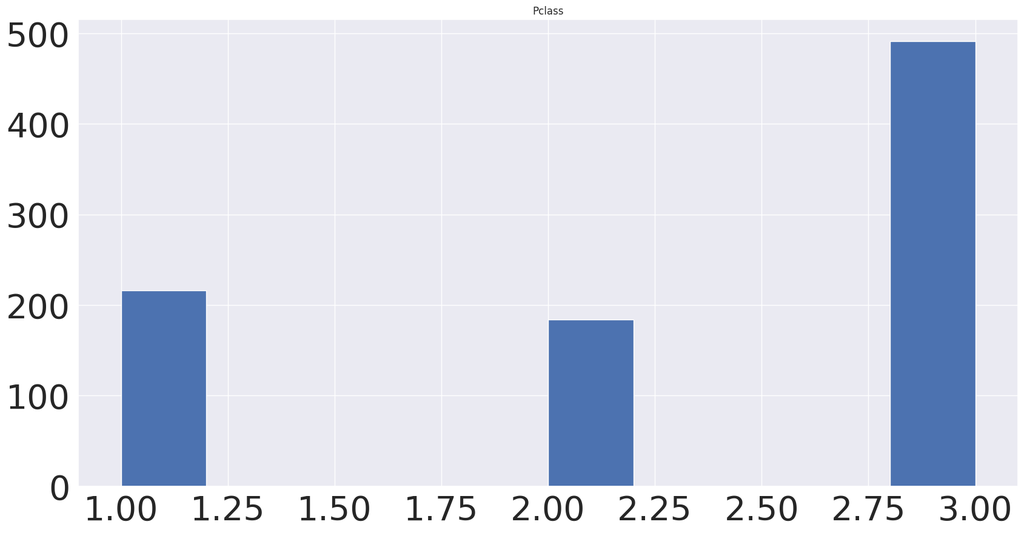

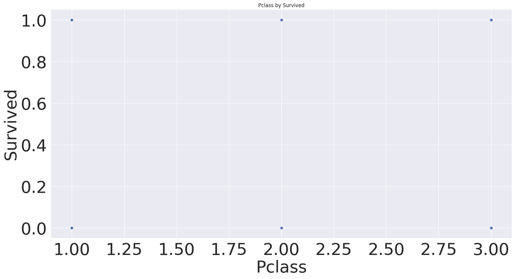

```python
titanic_df.hist('Pclass' ,bins=10)
def plot_connection_between_2_features(df,
                                       feature_1_name,
                                       feature_2_name):
    df.plot.scatter(x=feature_1_name,
                    y=feature_2_name,
                    title=f'{feature_1_name} by {feature_2_name}')

plot_connection_between_2_features(titanic_df, 'Pclass', 'Survived')
```

2.Age

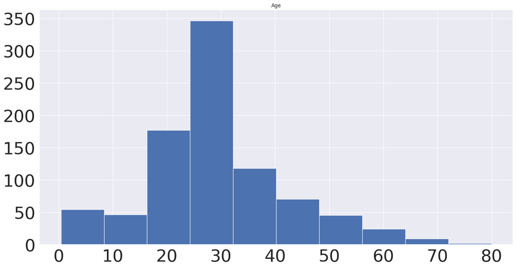

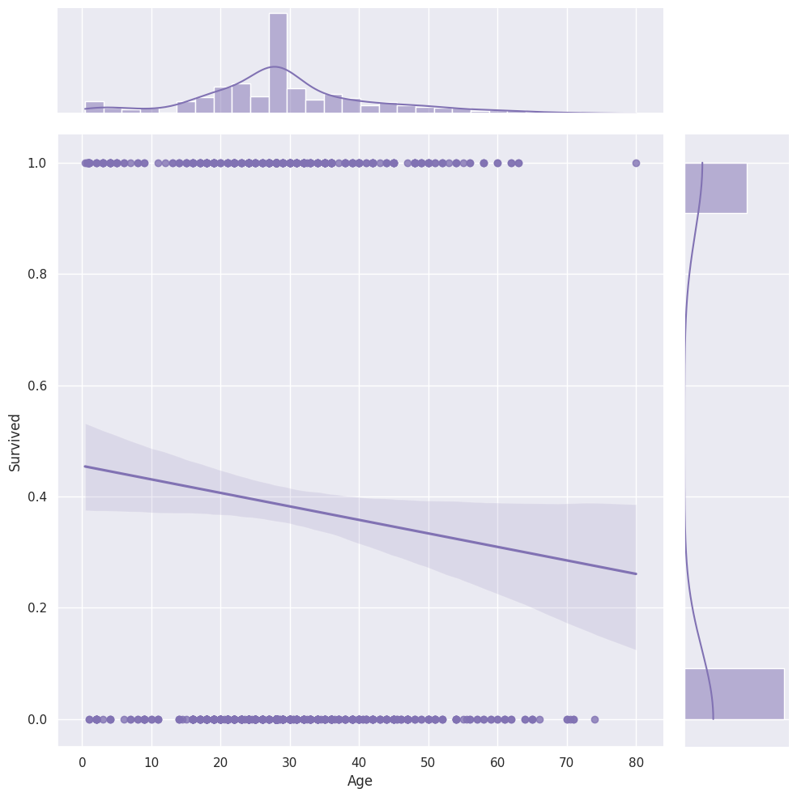

```python
titanic_df.hist('Age' ,bins=10)
sns.set_theme(style="darkgrid")
g = sns.jointplot(x="Age", y="Survived", data=titanic_df, kind="reg", color="m", height=10)
```

here we can see the majority of ages is bitween 20-30 (the max count of an age group is almost 350) we can see that the older that you are - the less you survived in the titanic.

3. Fare:

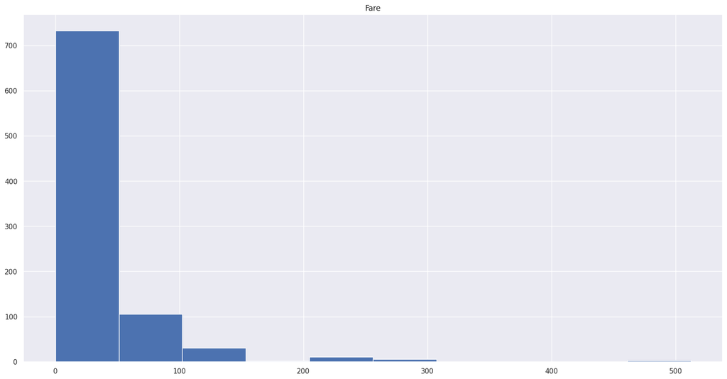

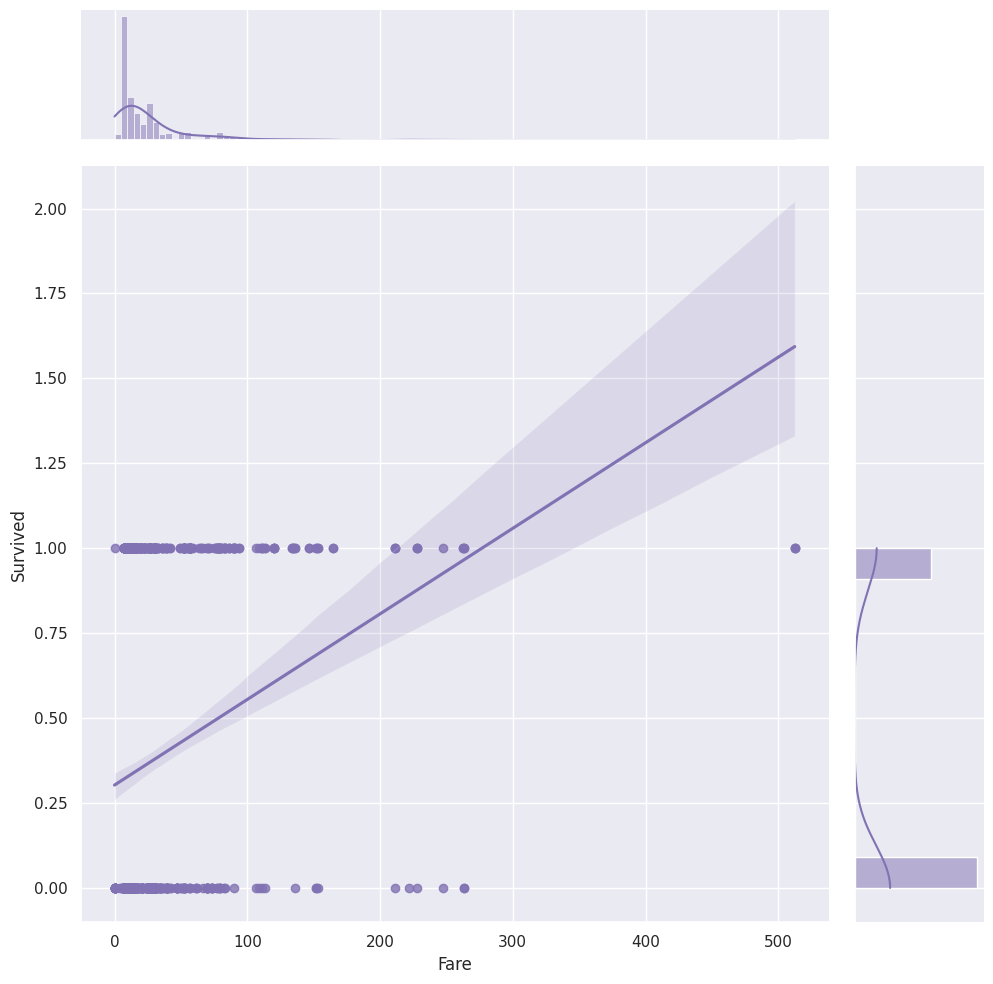

```python
titanic_df.hist('Fare' ,bins=10)
sns.set_theme(style="darkgrid")
g = sns.jointplot(x="Fare", y="Survived", data=titanic_df, kind="reg", color="m", height=10)
```

Most people paid a low price for the trip, you can see from the graph that the higher the price you pay, the more likely you are to survive the trip, but the graph is a bit out of bounds so you can't draw the conclusion so easily

4.sex (are you a male of not)

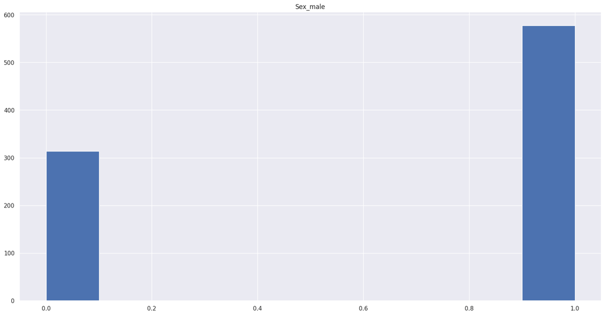

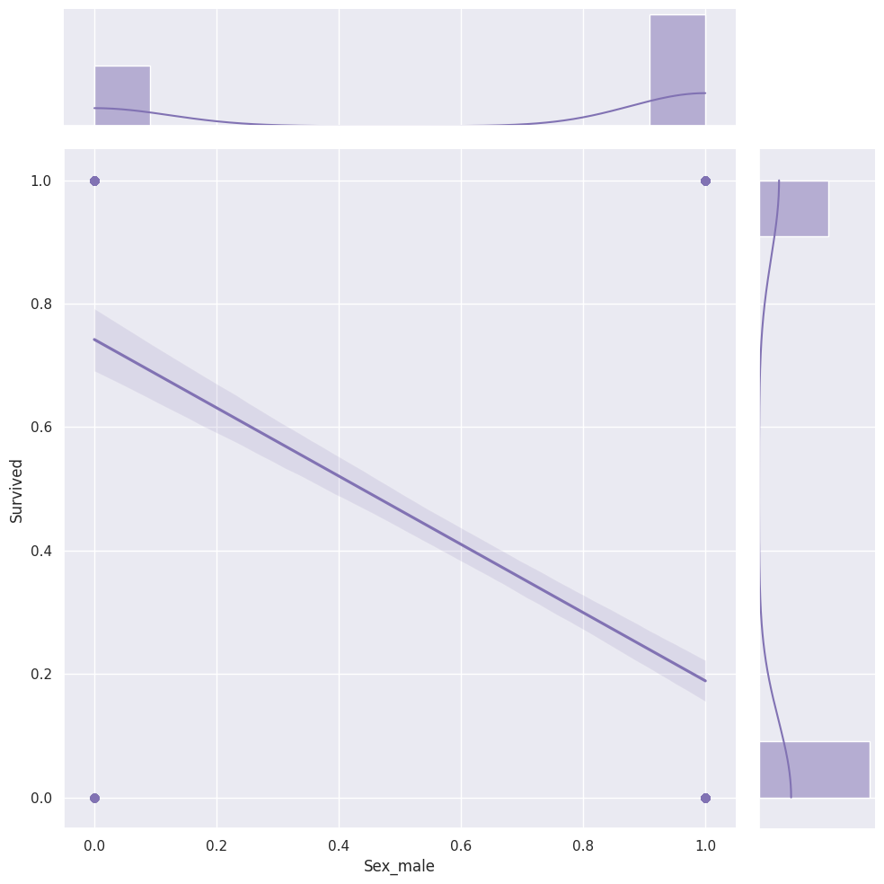

```python
titanic_df.hist('Sex_male' ,bins=10)
sns.set_theme(style="darkgrid")
g = sns.jointplot(x="Sex_male", y="Survived", data=titanic_df, kind="reg", color="m", height=10)
```

Most of the passengers are men, but in the collision graph you can see that the men are the least likely to survive the trip

5.embarked - Here I changed the category a bit and made it numerical: 2-S C-0 Q-1

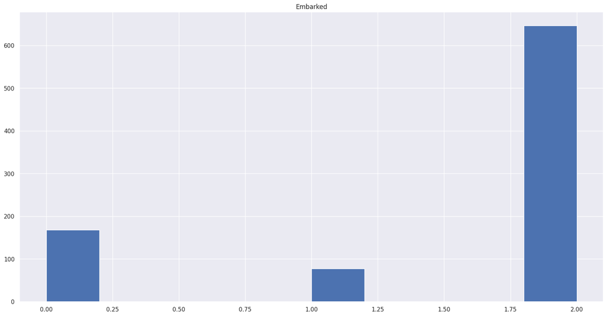

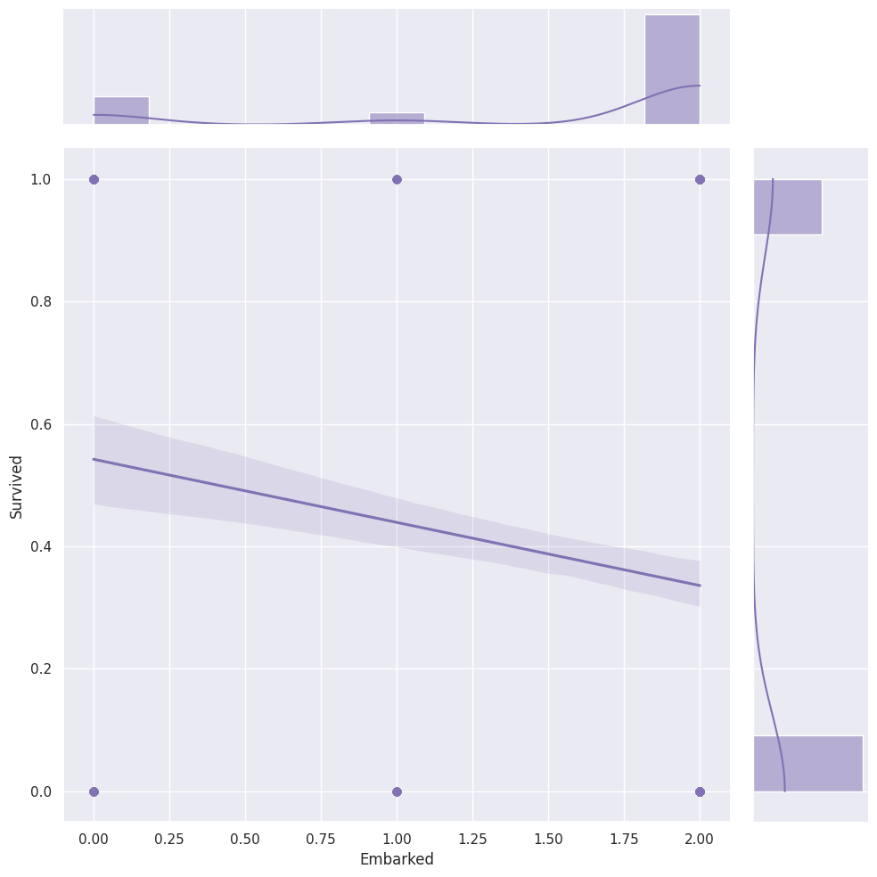

```python
titanic_df.hist('Embarked' ,bins=10)
sns.set_theme(style="darkgrid")
g = sns.jointplot(x="Embarked", y="Survived", data=titanic_df, kind="reg", color="m", height=10)
```

6.sibsp & parch:

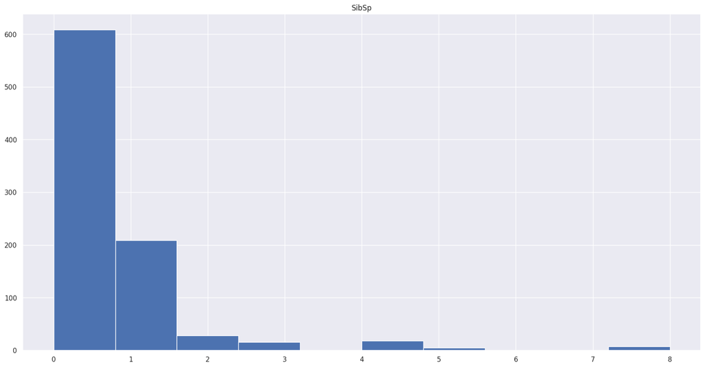

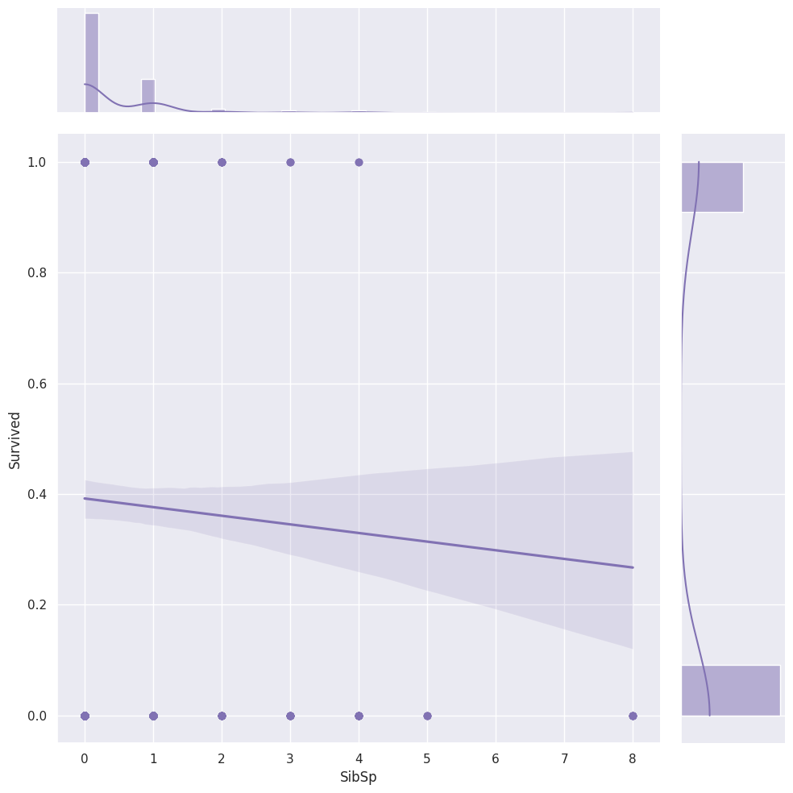

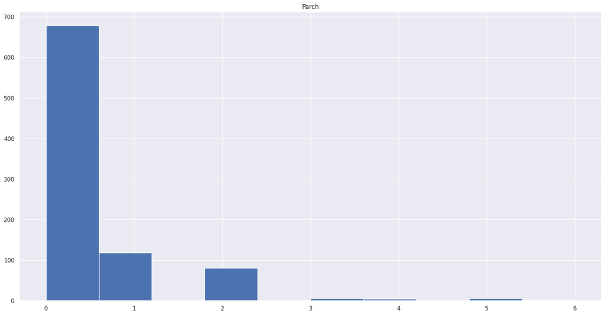

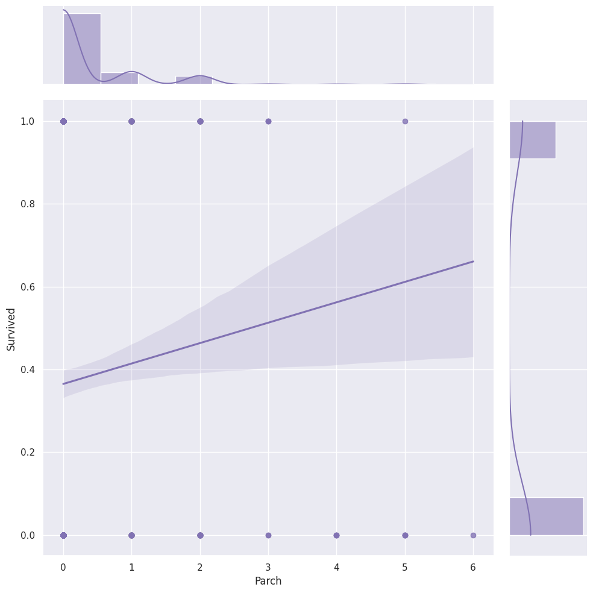

```python
titanic_df.hist('SibSp' ,bins=10)
sns.set_theme(style="darkgrid")
g = sns.jointplot(x="SibSp", y="Survived", data=titanic_df, kind="reg", color="m", height=10)


titanic_df.hist('Parch' ,bins=10)
sns.set_theme(style="darkgrid")
g = sns.jointplot(x="Parch", y="Survived", data=titanic_df, kind="reg", color="m", height=10)
```

Here you can see that most of the passengers were single, that is, there were few families on this trip according to the numbers of siblings and parents, you can see that the more parents and fewer siblings you have, the more you will survive

It is possible to understand how the information works around the question of whether the passenger will survive or not, we will reduce the rest of the information to one map so as not to burden

# let's see all the data in a map:

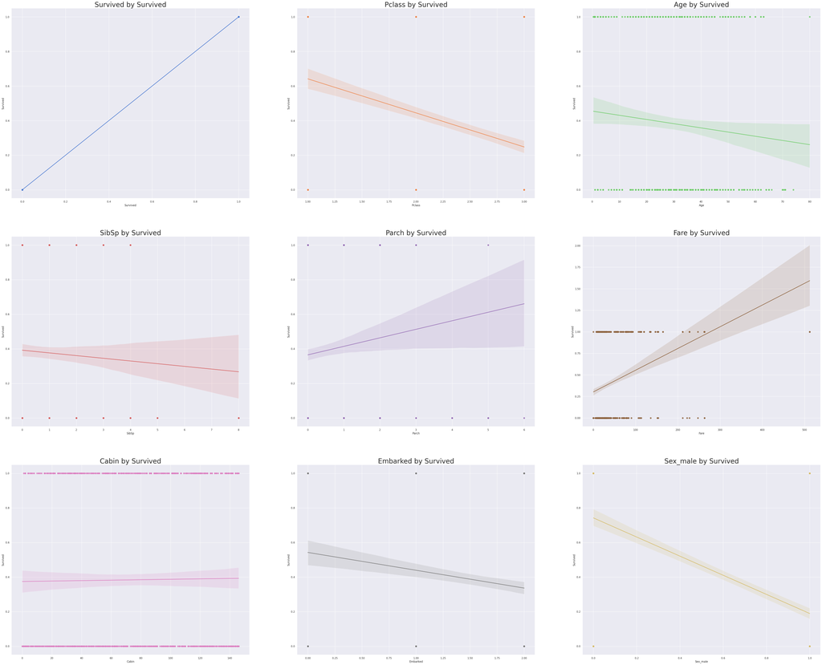

```python
# get color map
def get_sns_cmap(n, name='muted'):
  return sns.color_palette(palette=name, n_colors=n)

# plot with regression line target values by each feature
def plot_reg_target_values_by_each_feature(df, target_column_name):
  nrows = math.ceil(math.sqrt(len(df.columns)-1))
  ncols = math.ceil((len(df.columns)-1)/nrows)
  fig, axes = plt.subplots(nrows, ncols)
  plt.subplots_adjust(top=6.0, bottom=2, left=2, right=4.5)
  colors = get_sns_cmap(len(df.columns))

  for i in range(len(df.columns)):
    ax = sns.regplot(x=df.columns[i], y=target_column_name, data=df, color=colors[i], ax=axes[i//nrows, i%nrows], scatter_kws={"s": 40})
    ax.set_title(label=f'{df.columns[i]} by {target_column_name}', fontsize=30)

  for i in range(len(df.columns), nrows*ncols):
    fig.delaxes(axes.flatten()[i])
plot_reg_target_values_by_each_feature(titanic_df, 'Survived')
```

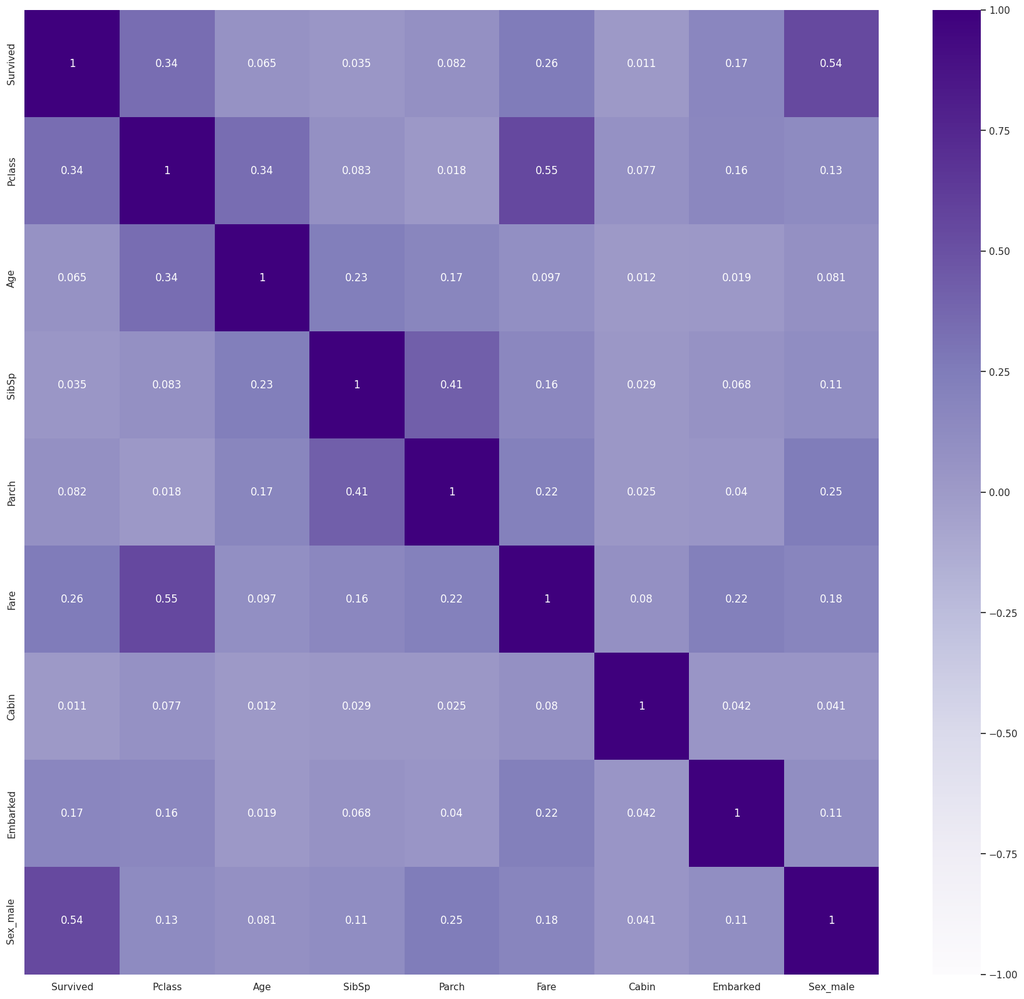

```python
plt.figure(figsize=(22,20))
cor = np.abs(titanic_df.corr())
#cor = titanic_df.corr()
sns.heatmap(cor, annot=True,cmap=plt.cm.Purples,
            vmin=-1, vmax=1)
plt.show()
```

FarePerPclass = Fare / Pclass

```python
# show absolute correlation between features (with the new size feature) in a heatmap
scaler = StandardScaler()
titanic_df_cp = titanic_df.copy()
titanic_df_test_cp = titanic_df.copy()
titanic_df_cp.insert(len(titanic_df.columns) ,'FarePerPclass', titanic_df['Fare'] / titanic_df['Pclass'])
titanic_df_test_cp.insert(len(titanic_df_test.columns),'FarePerPclass', titanic_df_test['Fare'] / titanic_df_test['Pclass'])

normelize_data(titanic_df_cp ,'FarePerPclass')
normelize_data(titanic_df_test_cp ,'FarePerPclass')

#titanic_df_test_cp['FarePerPclass'] = scaler.fit(titanic_df_test_cp['FarePerPclass'])
```

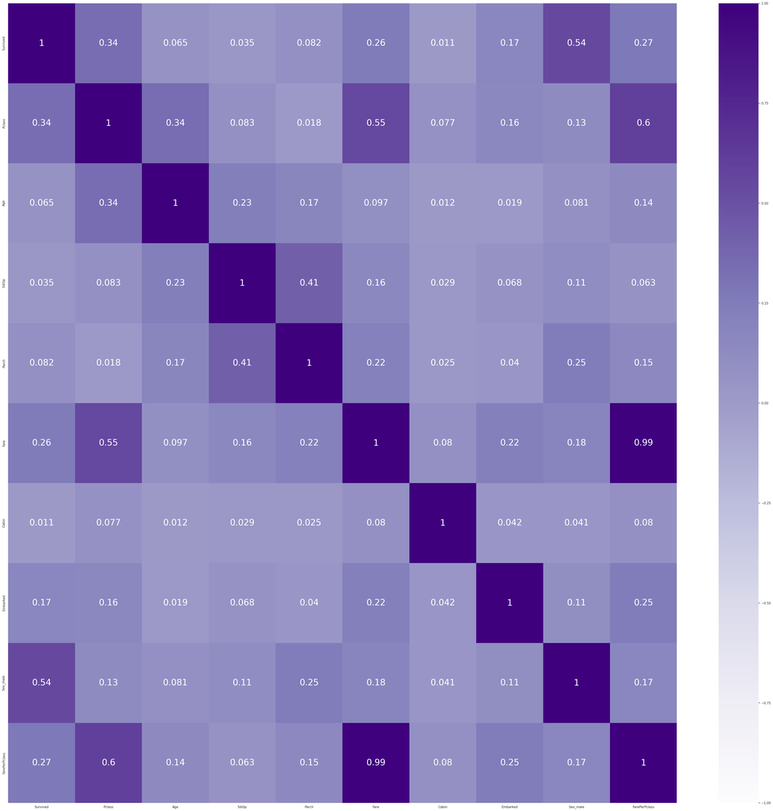

```python
#hit map again:
plt.figure(figsize=(52,50))
cor = np.abs(titanic_df_cp.corr())
#cor = titanic_df.corr()
sns.heatmap(cor, annot=True,cmap=plt.cm.Purples,
            vmin=-1, vmax=1 ,annot_kws={"fontsize": 30})
plt.show()
```

The absolute correlation between the new FarePerPclass attribute and the target is 0.27, relative to other attributes in the train data, this attribute is considered a good correlation to the target, so we will try to integrate train_cp in the experiment in the next step.

# data slicing:

```python
def print_graphs_r2_ce(graph_points):
  for k, v in graph_points.items():
    best_value = max(v.values()) if 'R2' in k else min(v.values())
    best_index = np.argmax(list(v.values())) if 'R2' in k else np.argmin(list(v.values()))
    color = 'r' if 'train' in k else 'b'
    plt.rcParams["figure.figsize"] = (16, 8)
    plt.plot(list(v.keys()), list(v.values()), color)
    plt.grid()
    plt.xlabel('X')
    plt.ylabel('Y')
    plt.title(f'{k}, best value: x={best_index + 1}, y={best_value}', fontsize=20)
    plt.show()
# plot the score by split and the loss by split for SGD
def plot_score_and_loss_by_split_SGD(x, t):
  graph_points = { 'train_CE': {}, 'val_CE': {}, 'train_R2': {}, 'val_R2': {} }

  for size in range(10, 100, 10):
    x_train, x_val, t_train, t_val = model_selection.train_test_split(x, t, test_size=size/100, random_state=42)
    SGD_cls = pipeline.make_pipeline(preprocessing.StandardScaler(), linear_model.SGDClassifier(loss='log', alpha=0, learning_rate='constant', eta0=0.01)).fit(x_train, t_train)
    y_train_prob = SGD_cls.predict_proba(x_train)
    y_test_prob = SGD_cls.predict_proba(x_val)
    y_train = SGD_cls.predict(x_train)
    y_val = SGD_cls.predict(x_val)
    graph_points['train_CE'][size/100] = metrics.log_loss(t_train, y_train_prob)
    graph_points['val_CE'][size/100] = metrics.log_loss(t_val, y_test_prob)
    graph_points['train_R2'][size/100] = SGD_cls.score(x_train, t_train)
    graph_points['val_R2'][size/100] = SGD_cls.score(x_val, t_val)
  print_graphs_r2_ce(graph_points)

def plot_score_and_loss_by_split_MLP(x, t):
  graph_points = { 'train_CE': {}, 'val_CE': {}, 'train_R2': {}, 'val_R2': {} }

  for size in range(10, 100, 10):
    x_train, x_val, t_train, t_val = model_selection.train_test_split(x, t, test_size=size/100, random_state=42)
    MLP_cls = neural_network.MLPClassifier(activation='logistic', solver='sgd', alpha=0, max_iter=40000).fit(x_train, t_train)
    y_train_prob = MLP_cls.predict_proba(x_train)
    y_test_prob = MLP_cls.predict_proba(x_val)
    graph_points['train_CE'][size/100] = metrics.log_loss(t_train, y_train_prob)
    graph_points['val_CE'][size/100] = metrics.log_loss(t_val, y_test_prob)
    graph_points['train_R2'][size/100] = MLP_cls.score(x_train, t_train)
    graph_points['val_R2'][size/100] = MLP_cls.score(x_val, t_val)
  print_graphs_r2_ce(graph_points)
```

```python
#data slicing:

t = titanic_df['Survived']
X = titanic_df.drop('Survived', axis=1)
print('t')
display(t)
print()
print('x')
display(X)
```

```
t
```

```
0      0
1      1
2      1
3      1
4      0
      ..
886    0
887    1
888    0
889    1
890    0
Name: Survived, Length: 891, dtype: int64
```

```
x
```

|  | Pclass | Age | SibSp | Parch | Fare | Cabin | Embarked | Sex_male |
| --- | --- | --- | --- | --- | --- | --- | --- | --- |
| 0 | 3 | 22.0 | 1 | 0 | 7.2500 | 112 | 2 | 1.0 |
| 1 | 1 | 38.0 | 1 | 0 | 71.2833 | 81 | 0 | 0.0 |
| 2 | 3 | 26.0 | 0 | 0 | 7.9250 | 102 | 2 | 0.0 |
| 3 | 1 | 35.0 | 1 | 0 | 53.1000 | 55 | 2 | 0.0 |
| 4 | 3 | 35.0 | 0 | 0 | 8.0500 | 20 | 2 | 1.0 |
| ... | ... | ... | ... | ... | ... | ... | ... | ... |
| 886 | 2 | 27.0 | 0 | 0 | 13.0000 | 40 | 2 | 1.0 |
| 887 | 1 | 19.0 | 0 | 0 | 30.0000 | 30 | 2 | 0.0 |
| 888 | 3 | 28.0 | 1 | 2 | 23.4500 | 145 | 2 | 0.0 |
| 889 | 1 | 26.0 | 0 | 0 | 30.0000 | 60 | 0 | 1.0 |
| 890 | 3 | 32.0 | 0 | 0 | 7.7500 | 131 | 1 | 1.0 |

891 rows × 8 columns

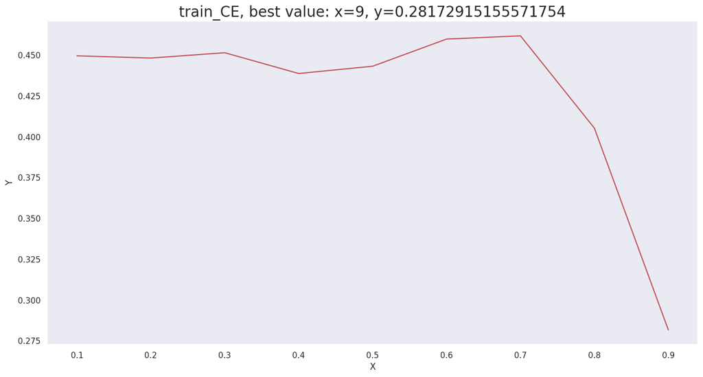

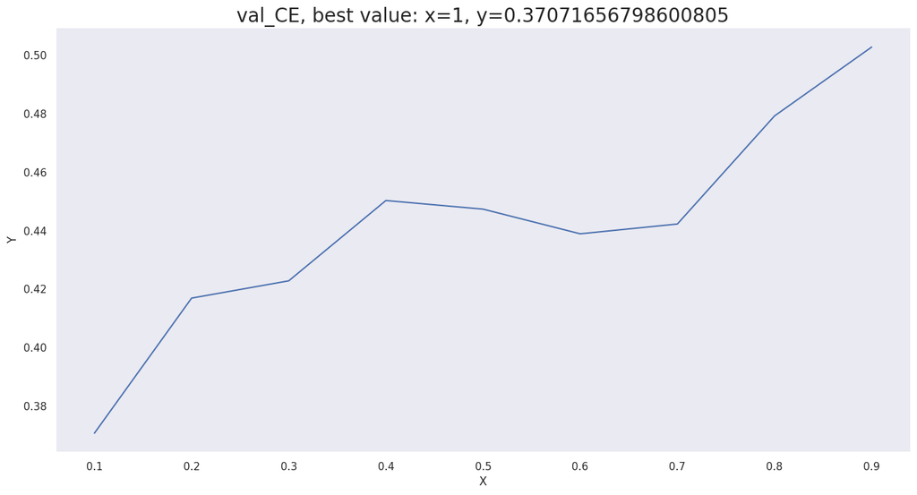

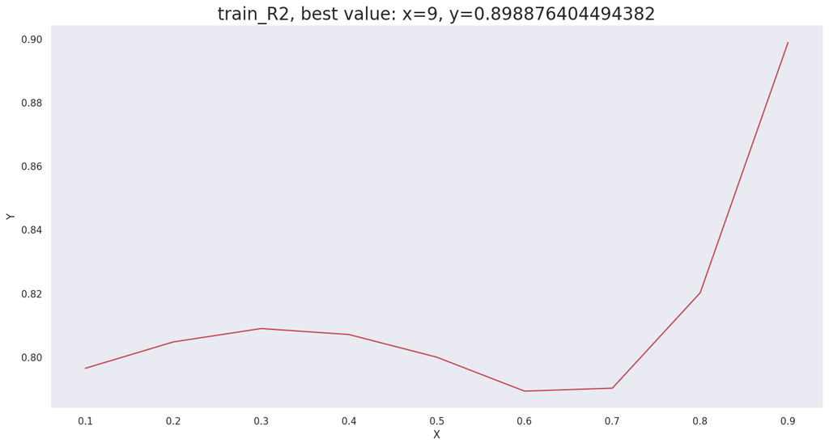

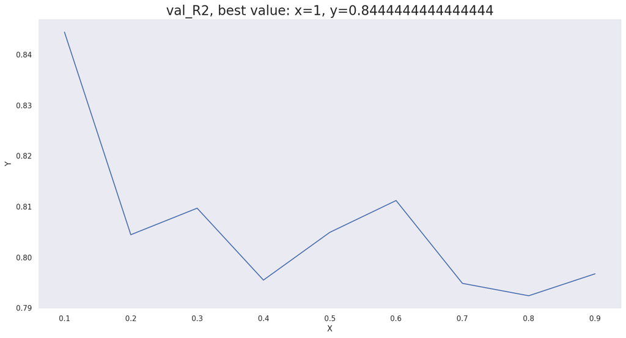

```python
# plot the train on SGD model be different slicing of the data
plot_score_and_loss_by_split_SGD(X, t)
```

```
t
```

```
0      0
1      1
2      1
3      1
4      0
      ..
886    0
887    1
888    0
889    1
890    0
Name: Survived, Length: 891, dtype: int64
```

```
x
```

|  | Pclass | Age | SibSp | Parch | Fare | Cabin | Embarked | Sex_male |
| --- | --- | --- | --- | --- | --- | --- | --- | --- |
| 0 | 3 | 22.0 | 1 | 0 | 7.2500 | 112 | 2 | 1.0 |
| 1 | 1 | 38.0 | 1 | 0 | 71.2833 | 81 | 0 | 0.0 |
| 2 | 3 | 26.0 | 0 | 0 | 7.9250 | 102 | 2 | 0.0 |
| 3 | 1 | 35.0 | 1 | 0 | 53.1000 | 55 | 2 | 0.0 |
| 4 | 3 | 35.0 | 0 | 0 | 8.0500 | 20 | 2 | 1.0 |
| ... | ... | ... | ... | ... | ... | ... | ... | ... |
| 886 | 2 | 27.0 | 0 | 0 | 13.0000 | 40 | 2 | 1.0 |
| 887 | 1 | 19.0 | 0 | 0 | 30.0000 | 30 | 2 | 0.0 |
| 888 | 3 | 28.0 | 1 | 2 | 23.4500 | 145 | 2 | 0.0 |
| 889 | 1 | 26.0 | 0 | 0 | 30.0000 | 60 | 0 | 1.0 |
| 890 | 3 | 32.0 | 0 | 0 | 7.7500 | 131 | 1 | 1.0 |

891 rows × 8 columns

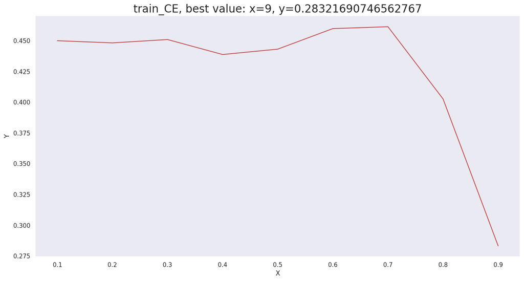

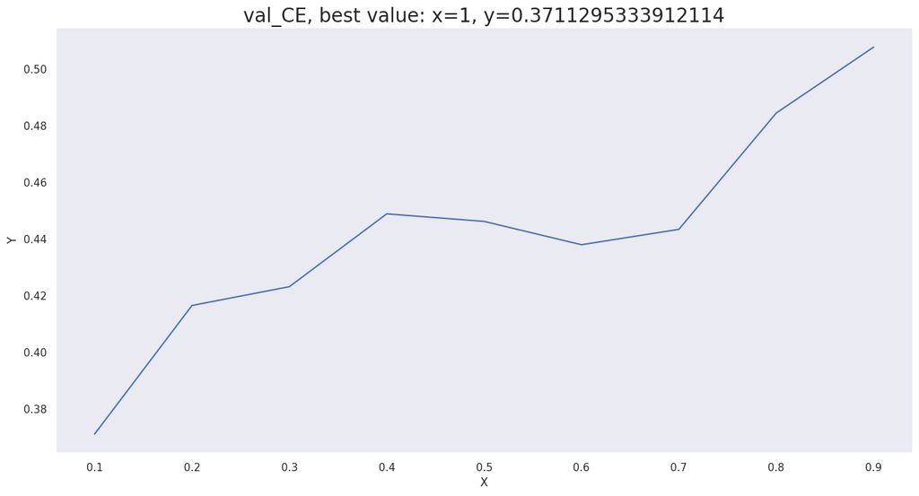

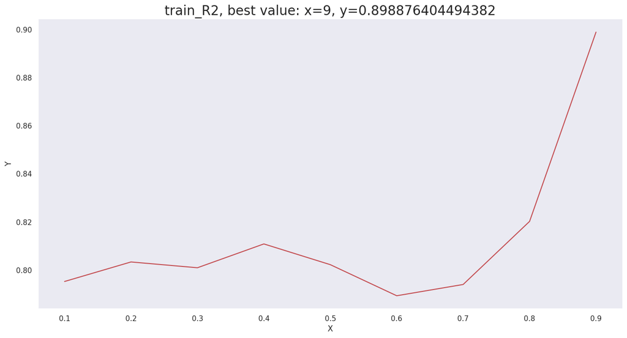

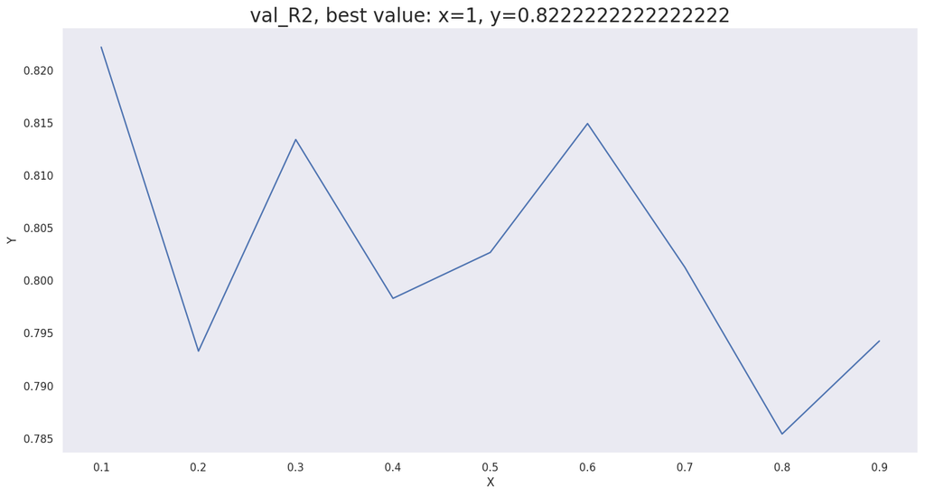

```python
t_cp = titanic_df_cp['Survived']
x_cp = titanic_df_cp.drop('Survived', axis=1)
print('t')
display(t)
print()
print('x')
display(X)
# plot the train_cp on SGD model be different slicing of the data
plot_score_and_loss_by_split_SGD(x_cp, t_cp)
```

```python
X_train, X_test, t_train, t_test = sklearn.model_selection.train_test_split(X, t, test_size=0.25, random_state=42)

#tarining the model:

# create the SGDClassifier and predict the probabilities of the train and test data
SGD_cls = pipeline.make_pipeline(
    preprocessing.StandardScaler(),
     linear_model.SGDClassifier(loss='log_loss', alpha=0,
                                learning_rate='constant',
                                eta0=0.01)
     ).fit(X_train, t_train)

# predict probabilities
y_train_prob = SGD_cls.predict_proba(X_train)
y_test_prob = SGD_cls.predict_proba(X_test)

# predicting test and train test results
y_train = SGD_cls.predict(X_train)
y_test = SGD_cls.predict(X_test)

print('first 5 probabilities of y_train_prob:')
print(y_train_prob[:5])
print()
print('first 5 predictions of y_train:')
print(y_train[:5])
print()
print('first 5 probabilities of y_test_prob:')
print(y_test_prob[:5])
print()
print('first 5 predictions of y_test:')
print(y_test[:5])
```

```
first 5 probabilities of y_train_prob:
[[0.54595436 0.45404564]
 [0.88711348 0.11288652]
 [0.20269968 0.79730032]
 [0.86215831 0.13784169]
 [0.38844944 0.61155056]]

first 5 predictions of y_train:
[0 0 1 0 1]

first 5 probabilities of y_test_prob:
[[0.88582647 0.11417353]
 [0.78874881 0.21125119]
 [0.87008315 0.12991685]
 [0.11210045 0.88789955]
 [0.20660912 0.79339088]]

first 5 predictions of y_test:
[0 0 0 1 1]
```

```python
  def compare_pred_prettify(y_test_prob,t_test,y_test, class_A):
    # conver to float with 2-digit after zero
    y_test_prob = np.round(y_test_prob, 2)
    res = "{:<10} | {:<10} | {:<10}".format("t_test", "y_test", f"{class_A}(%)\n")
    res += "-"*65+"\n"
    res += "\n".join("{:<10} | {:<10} | {:<10}".format(x, y, a) for x, y, a in zip(t_test, y_test, y_test_prob[:,0]))
    res += "\n"+"-"*65+"\n"
    print(res)

  compare_pred_prettify(y_test_prob,t_test,y_test,'Survived')
```

[output not shown]

[output cut: 211 more lines]

```python
print('Accuracy score on train',SGD_cls.score(X_train, t_train))
print('Accuracy score on test',SGD_cls.score(X_test, t_test))
print()
print('CE on train',metrics.log_loss(t_train, y_train_prob))
print('CE on test', metrics.log_loss(t_test, y_test_prob))
```

```
Accuracy score on train 0.8068862275449101
Accuracy score on test 0.8026905829596412

CE on train 0.44884517598978685
CE on test 0.42181657963384295
```

```python
#do the test:

SGD_cls = pipeline.make_pipeline(preprocessing.StandardScaler(), linear_model.SGDClassifier(loss='log', alpha=0, learning_rate='constant', eta0=0.01)).fit(X, t)
submission_preds = SGD_cls.predict(titanic_df_test)

gender_submition['Survived'] = submission_preds
gender_submition.to_csv('submission.csv', index=False)
gender_submition
```

|  | PassengerId | Survived |
| --- | --- | --- |
| 0 | 892 | 0 |
| 1 | 893 | 0 |
| 2 | 894 | 0 |
| 3 | 895 | 0 |
| 4 | 896 | 1 |
| ... | ... | ... |
| 413 | 1305 | 0 |
| 414 | 1306 | 1 |
| 415 | 1307 | 0 |
| 416 | 1308 | 0 |
| 417 | 1309 | 0 |

418 rows × 2 columns